# Prova

Rafael Silva Wagner

3 de novembro de 2017

```r
library(BETS)
library(forecast)
library(stats)
library(MTS)
library(xts)
library(tseries)
library(ggplot2)
library(moments)
library(MCMCpack)
library(plot3D)
library(vars)
library(egcm)
library(PerformanceAnalytics)
library(ggfortify)
library(quantmod)
library(mgarchBEKK)
library(quantmod)
library(ccgarch)
library(rmgarch)
library(BatchGetSymbols)
library(gridExtra)
```

Escolhi trabalhar com indices de ações europeias, escolhi elas pois acredito que elas podem conter informações relevantes tanto para análise de correção de erros uma vez que a economia europeia é muito integrada, quanto podem apresentar características relevantes na análise de variancia. Farei as duas questões com os indices da Inglaterra, França, Suíça, Alemanha, Holanda

Comecemos carregandos essas séries

```r
#^GDAXI - DAX - Alemanha
#^FTSE - FTSE - Inglaterra
#^AEX - AEX - Holanda
#^FCHI - CAC 40 - França
#^SSMI - SMI - Suíça
symbols <- c("^GDAXI","^FTSE","^AEX","^FCHI","^SSMI")
getSymbols(symbols, src = 'yahoo', from = "2007-01-01",auto.assign = TRUE, warnings = FALSE)
prices <- merge(AEX,FCHI,FTSE,GDAXI,SSMI)
prices <- prices[,grepl( "Close" , names(prices) )]
#Da uma limpada nos espaços em branco
limpeza<-as.matrix(prices)
impute.mean <- function(x) replace(x, is.na(x) | is.nan(x) | is.infinite(x), mean(x, na.rm = TRUE))
limpeza <- apply(limpeza, 2, impute.mean)
impute.mean <- function(x) replace(x, is.na(x) | is.nan(x) | is.infinite(x), mean(x[!is.na(x) & !is.nan(x) & !is.infinite(x)]))
limpeza <- apply(limpeza, 2, impute.mean)
#devolve as séries limpas para um data.frame
prices<-as.xts(limpeza)
colnames(prices) <- symbols
returns <- na.omit(Return.calculate(prices, method = "log"))*100
```

# Letra a

Começamos plotando as séries antes sem tratamento

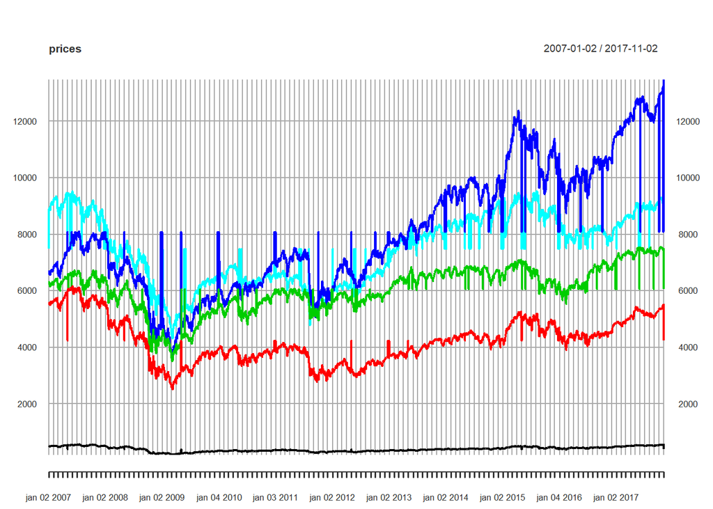

```r
plot.xts(prices)
```

Vemos que as oscilações realmente parecem ter algum comovimento, vamos agora realizar o teste ADF nessas séries.

```r
adf.test(prices[,1])
```

```
##
##  Augmented Dickey-Fuller Test
##
## data:  prices[, 1]
## Dickey-Fuller = -2.2401, Lag order = 14, p-value = 0.4767
## alternative hypothesis: stationary
```

```r
adf.test(prices[,2])
```

```
##
##  Augmented Dickey-Fuller Test
##
## data:  prices[, 2]
## Dickey-Fuller = -2.1886, Lag order = 14, p-value = 0.4985
## alternative hypothesis: stationary
```

```r
adf.test(prices[,3])
```

```
##
##  Augmented Dickey-Fuller Test
##
## data:  prices[, 3]
## Dickey-Fuller = -2.4838, Lag order = 14, p-value = 0.3735
## alternative hypothesis: stationary
```

```r
adf.test(prices[,4])
```

```
##
##  Augmented Dickey-Fuller Test
##
## data:  prices[, 4]
## Dickey-Fuller = -2.6123, Lag order = 14, p-value = 0.3191
## alternative hypothesis: stationary
```

```r
adf.test(prices[,5])
```

```
##
##  Augmented Dickey-Fuller Test
##
## data:  prices[, 5]
## Dickey-Fuller = -2.3224, Lag order = 14, p-value = 0.4418
## alternative hypothesis: stationary
```

Podemos ver que nenhuma das séries originais é de fato estacionária, nós ja pegamos os log-retornos dessas séries antes, vamos verificar se esse procedimento foi o suficiente para tornar todas as séries estacionárias.

```r
adf.test(returns[,1])
```

```
##
##  Augmented Dickey-Fuller Test
##
## data:  returns[, 1]
## Dickey-Fuller = -13.605, Lag order = 14, p-value = 0.01
## alternative hypothesis: stationary
```

```r
adf.test(returns[,2])
```

```
##
##  Augmented Dickey-Fuller Test
##
## data:  returns[, 2]
## Dickey-Fuller = -14.895, Lag order = 14, p-value = 0.01
## alternative hypothesis: stationary
```

```r
adf.test(returns[,3])
```

```
##
##  Augmented Dickey-Fuller Test
##
## data:  returns[, 3]
## Dickey-Fuller = -14.821, Lag order = 14, p-value = 0.01
## alternative hypothesis: stationary
```

```r
adf.test(returns[,4])
```

```
##
##  Augmented Dickey-Fuller Test
##
## data:  returns[, 4]
## Dickey-Fuller = -14.715, Lag order = 14, p-value = 0.01
## alternative hypothesis: stationary
```

```r
adf.test(returns[,5])
```

```
##
##  Augmented Dickey-Fuller Test
##
## data:  returns[, 5]
## Dickey-Fuller = -16.973, Lag order = 14, p-value = 0.01
## alternative hypothesis: stationary
```

Elas realmente estão com compotamento estacionário, agora quando quiser me referir as séries originais me referirei ao data frame prices, e quando quiser me referir as series estacionárias me referirei ao data frame returns.

Vamos montar uma tabela descritiva dos retornos e um gráfico deles conjuntamente.

```r
summary(data.frame(returns))
```

```
##     X.GDAXI              X.FTSE              X.AEX
##  Min.   :-45.20640   Min.   :-34.08565   Min.   :-33.36817
##  1st Qu.: -0.60431   1st Qu.: -0.68871   1st Qu.: -0.55920
##  Median :  0.04525   Median :  0.03041   Median :  0.03537
##  Mean   : -0.00852   Mean   : -0.01012   Mean   : -0.00149
##  3rd Qu.:  0.67124   3rd Qu.:  0.74391   3rd Qu.:  0.61881
##  Max.   : 49.55872   Max.   : 34.58924   Max.   : 35.55237
##      X.FCHI              X.SSMI
##  Min.   :-54.08435   Min.   :-34.26182
##  1st Qu.: -0.65266   1st Qu.: -0.56003
##  Median :  0.08162   Median :  0.04063
##  Mean   :  0.00683   Mean   :  0.00769
##  3rd Qu.:  0.73048   3rd Qu.:  0.59900
##  Max.   : 55.70166   Max.   : 36.01449
```

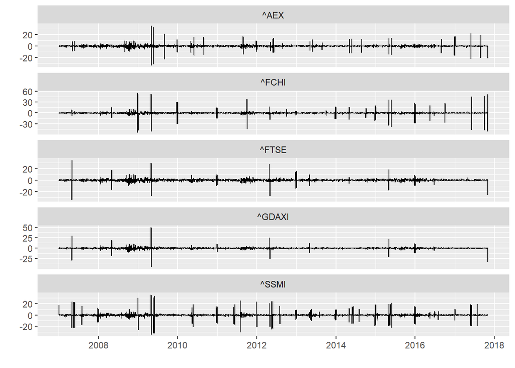

```r
autoplot(returns)
```

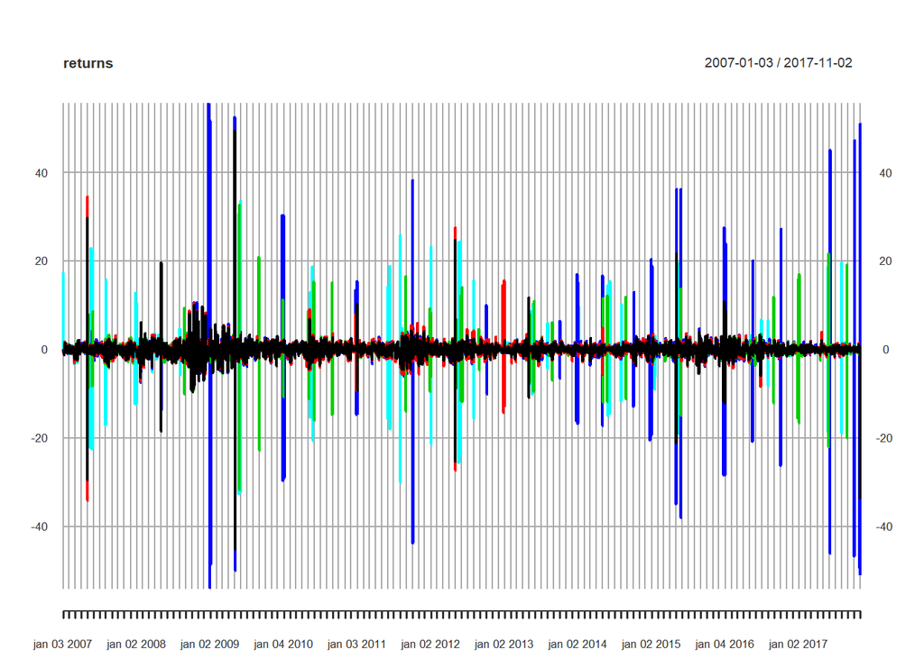

```r
plot.xts(returns)
```

Vamos analisar o histograma de cada série individualmente. Conjuntamente solicitarei os 4 primeiros momentos de cada serie.

```r
all.moments(returns[,1],order=3)
```

```
##              [,1]
## [1,]  1.000000000
## [2,] -0.008520775
## [3,]  5.932215777
## [4,] -3.471212700
```

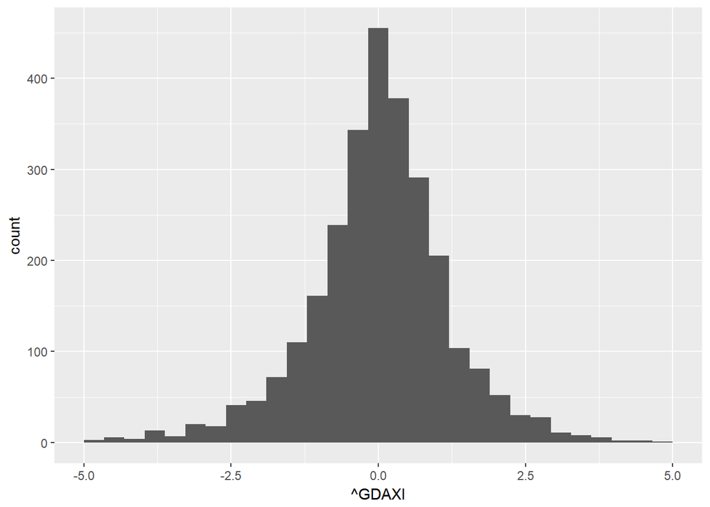

```r
qplot(returns[,1],qeom="histogram",xlim=c(-5,5),xlab=symbols[1])
```

```r
all.moments(returns[,2],order=3)
```

```
##             [,1]
## [1,]  1.00000000
## [2,] -0.01011866
## [3,]  5.41586312
## [4,] -2.40405650
```

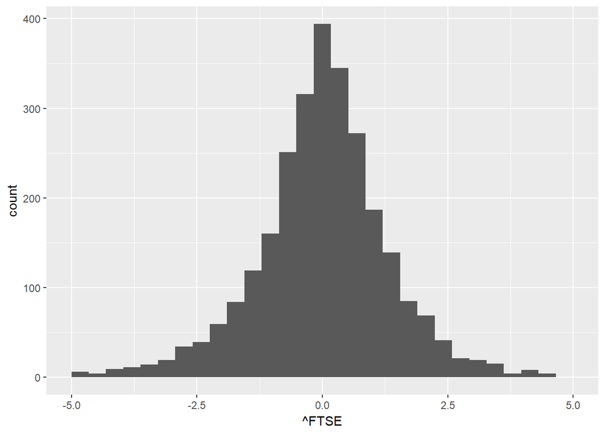

```r
qplot(returns[,2],qeom="histogram",xlim=c(-5,5),xlab=symbols[2])
```

```r
all.moments(returns[,3],order=3)
```

```
##              [,1]
## [1,]  1.000000000
## [2,] -0.001488392
## [3,]  6.671807080
## [4,] -0.119150012
```

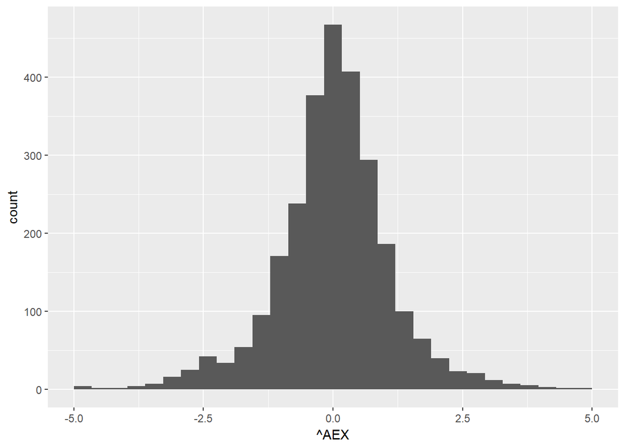

```r
qplot(returns[,3],qeom="histogram",xlim=c(-5,5),xlab=symbols[3])
```

```r
all.moments(returns[,4],order=3)
```

```
##               [,1]
## [1,]   1.000000000
## [2,]   0.006830187
## [3,]  22.165295904
## [4,] -33.438280728
```

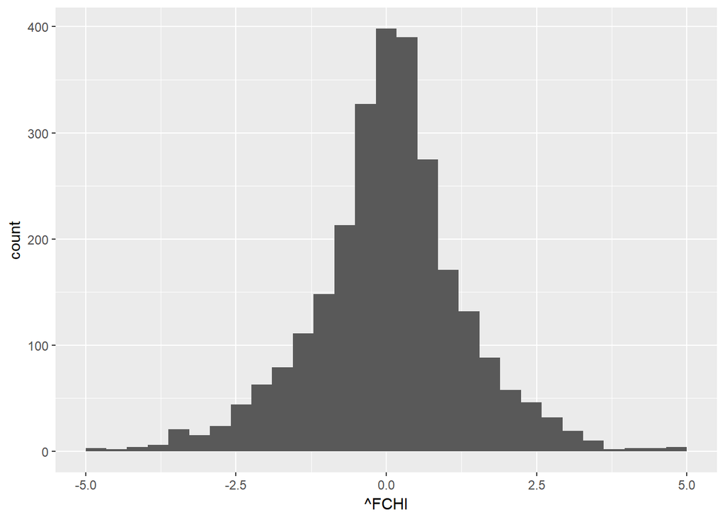

```r
qplot(returns[,4],qeom="histogram",xlim=c(-5,5),xlab=symbols[4])
```

```r
all.moments(returns[,5],order=3)
```

```
##              [,1]
## [1,]  1.000000000
## [2,]  0.007688649
## [3,] 12.805093361
## [4,]  3.158414278
```

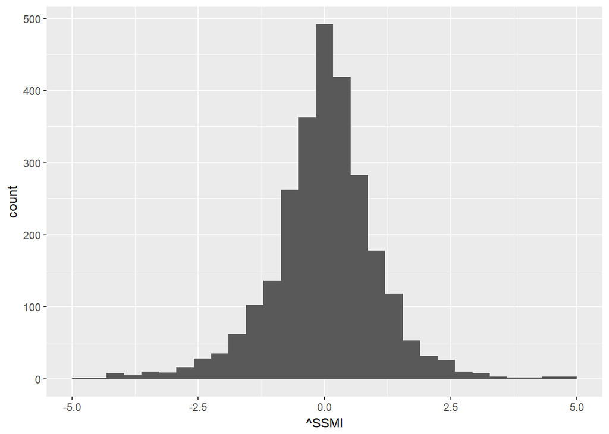

```r
qplot(returns[,5],qeom="histogram",xlim=c(-5,5),xlab=symbols[5])
```

Agora vamos verificar alguns gráficos que expçoe as autocorrelações presentes dentro de cada série.

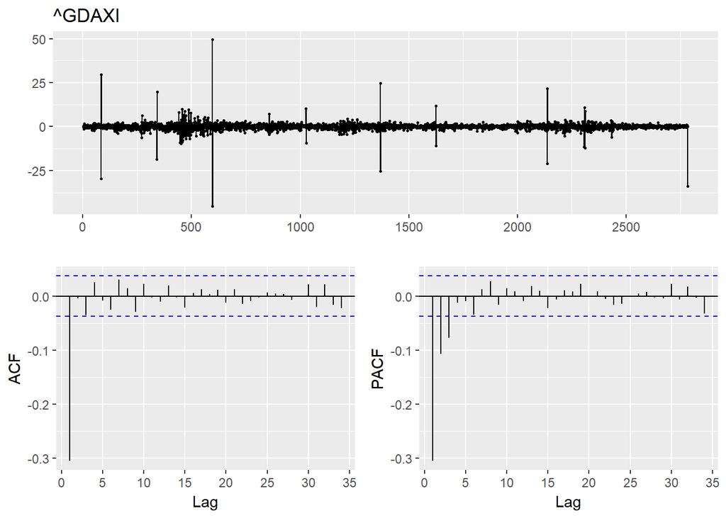

```r
ggtsdisplay(returns[,1],main=symbols[1])
```

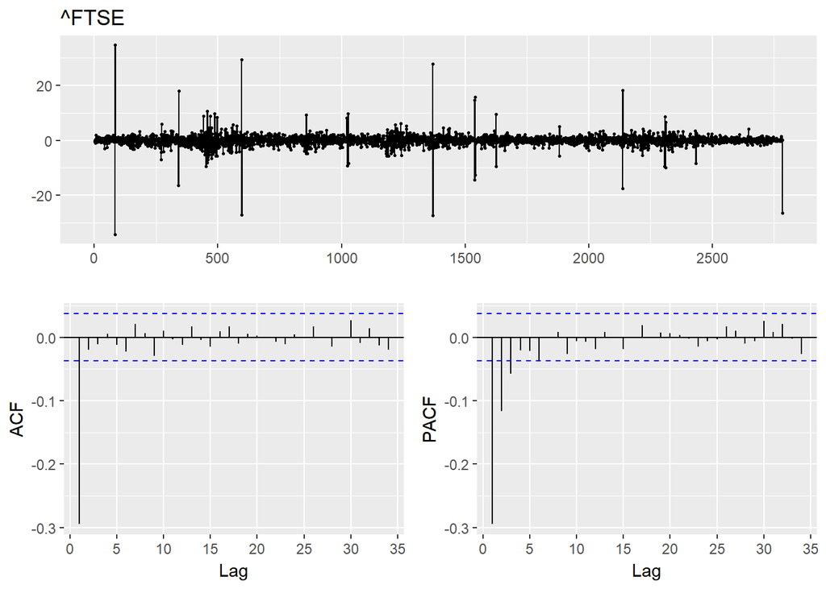

```r
ggtsdisplay(returns[,2],main=symbols[2])
```

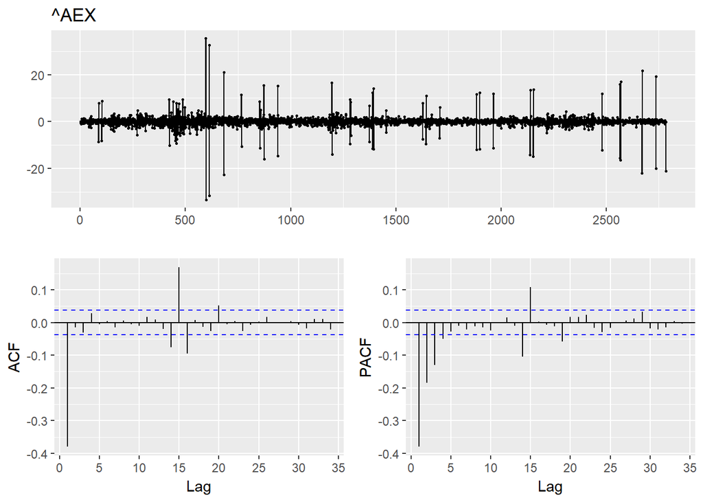

```r
ggtsdisplay(returns[,3],main=symbols[3])
```

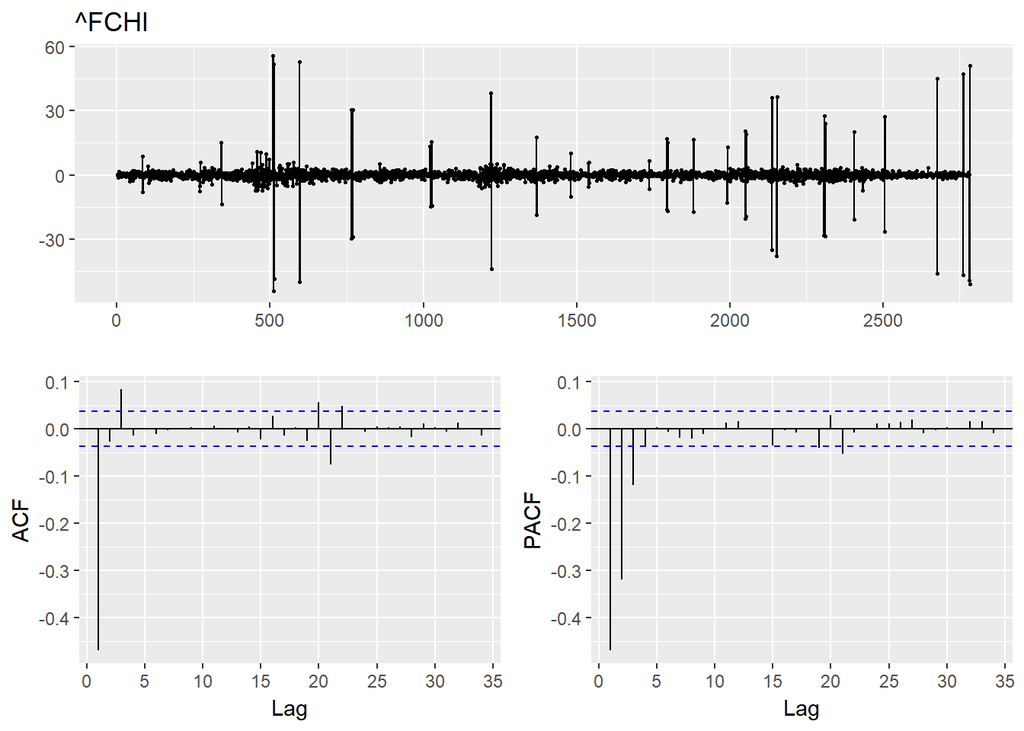

```r
ggtsdisplay(returns[,4],main=symbols[4])
```

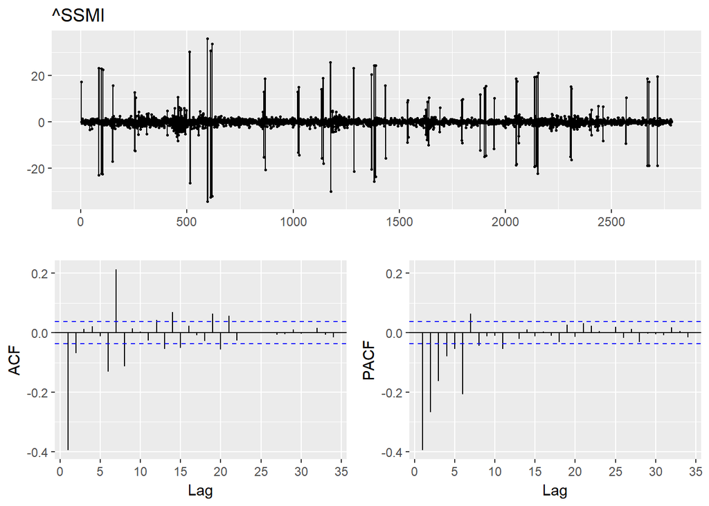

```r
ggtsdisplay(returns[,5],main=symbols[5])
```

# Letra b

Eu espero que essas séries tenham fortissimas relações, a economia europeia é muito relacionada especialmente pelo fato de alguns países que estamos analisando fazerem parte da zona do euro. Ainda aqueles que não fazem parte da zona do euro são muito influenciados por ela pois estão geograficamente muito próximos e tem relações economicas estreitas.

# Letra C

Vamos primeiramente verificar qual seria um bom número de defasagens, pedirei para serem avaliadas as primeiras 10 defasagens e plotarei os critérios de informação calculados.

```r
identificando<-VARselect(returns, lag.max=10)
identificando
```

```
## $selection
## AIC(n)  HQ(n)  SC(n) FPE(n)
##      8      6      6      8
##
## $criteria
##                  1           2          3          4          5          6
## AIC(n)    7.514366    7.039611   6.892663   6.821685   6.793391   6.704238
## HQ(n)     7.537518    7.082057   6.954402   6.902718   6.893717   6.823858
## SC(n)     7.578476    7.157146   7.063623   7.046070   7.071201   7.035474
## FPE(n) 1834.204683 1140.944230 985.021533 917.531140 891.935418 815.860126
##                 7          8          9         10
## AIC(n)   6.693576   6.689282   6.697558   6.697595
## HQ(n)    6.832490   6.847489   6.875058   6.894389
## SC(n)    7.078237   7.127368   7.189068   7.242531
## FPE(n) 807.209803 803.753761 810.436369 810.471180
```

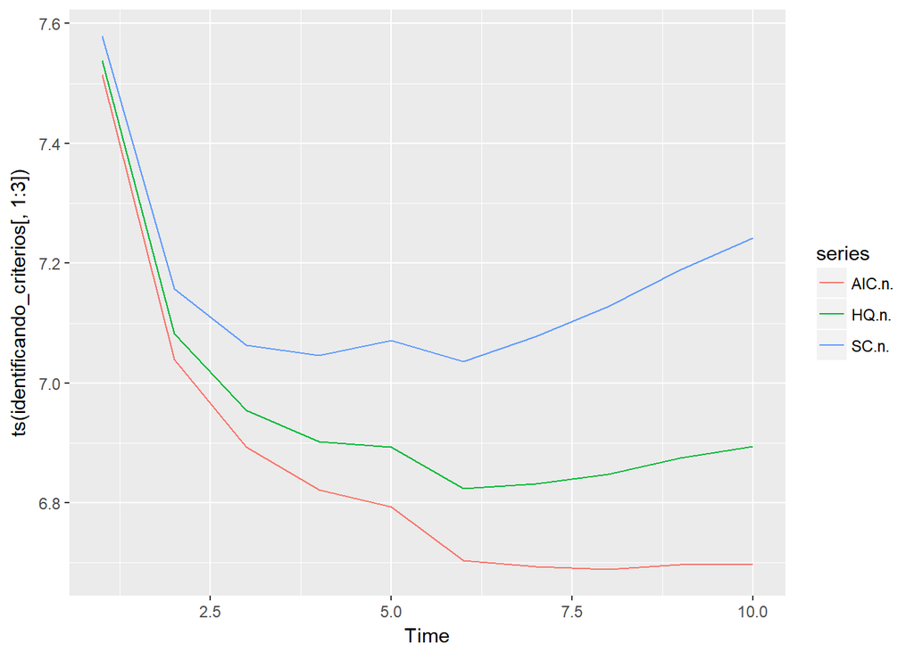

```r
identificando_criterios<-(data.frame(t(identificando$criteria)))
autoplot(ts(identificando_criterios[,1:3]))
```

Com essas informações e tentando ser parsimonioso escolhi estimar o modelo com 6 defasagens, número ótimo indicado pelo critério de informação bayesiano e pelo hanna-quin.

Vamos estimar esse VAR

```r
var_europa <- vars::VAR(returns, 6,type="none")
summary(var_europa)
```

```
##
## VAR Estimation Results:
## =========================
## Endogenous variables: X.GDAXI, X.FTSE, X.AEX, X.FCHI, X.SSMI
## Deterministic variables: none
## Sample size: 2778
## Log Likelihood: -28860.688
## Roots of the characteristic polynomial:
## 0.8182 0.8182 0.7847 0.7847 0.767 0.767 0.7202 0.7202 0.7159 0.7159 0.6753 0.6753 0.627 0.627 0.6255 0.6255 0.6106 0.6106 0.6024 0.6024 0.5693 0.5693 0.5647 0.5647 0.5166 0.5166 0.4847 0.4847 0.4519 0.4519
## Call:
## vars::VAR(y = returns, p = 6, type = "none")
##
##
## Estimation results for equation X.GDAXI:
## ========================================
## X.GDAXI = X.GDAXI.l1 + X.FTSE.l1 + X.AEX.l1 + X.FCHI.l1 + X.SSMI.l1 + X.GDAXI.l2 + X.FTSE.l2 + X.AEX.l2 + X.FCHI.l2 + X.SSMI.l2 + X.GDAXI.l3 + X.FTSE.l3 + X.AEX.l3 + X.FCHI.l3 + X.SSMI.l3 + X.GDAXI.l4 + X.FTSE.l4 + X.AEX.l4 + X.FCHI.l4 + X.SSMI.l4 + X.GDAXI.l5 + X.FTSE.l5 + X.AEX.l5 + X.FCHI.l5 +…
##
##             Estimate Std. Error t value Pr(>|t|)
## X.GDAXI.l1 -0.544096   0.050648 -10.743  < 2e-16 ***
## X.FTSE.l1   0.096140   0.052672   1.825 0.068073 .
## X.AEX.l1    0.171231   0.022894   7.479 1.00e-13 ***
## X.FCHI.l1   0.011291   0.013685   0.825 0.409401
## X.SSMI.l1  -0.018686   0.017388  -1.075 0.282616
## X.GDAXI.l2 -0.454840   0.057165  -7.957 2.56e-15 ***
## X.FTSE.l2   0.142659   0.057865   2.465 0.013747 *
## X.AEX.l2    0.213446   0.028117   7.591 4.31e-14 ***
## X.FCHI.l2   0.065932   0.017904   3.682 0.000235 ***
## X.SSMI.l2  -0.047235   0.020767  -2.275 0.023009 *
## X.GDAXI.l3 -0.266989   0.058639  -4.553 5.52e-06 ***
## X.FTSE.l3   0.016645   0.059584   0.279 0.779990
## X.AEX.l3    0.167677   0.030461   5.505 4.04e-08 ***
## X.FCHI.l3   0.055520   0.020158   2.754 0.005922 **
## X.SSMI.l3  -0.040550   0.022307  -1.818 0.069196 .
## X.GDAXI.l4 -0.132907   0.058677  -2.265 0.023585 *
## X.FTSE.l4  -0.007537   0.059686  -0.126 0.899527
## X.AEX.l4    0.146256   0.030472   4.800 1.67e-06 ***
## X.FCHI.l4   0.065914   0.020411   3.229 0.001256 **
## X.SSMI.l4  -0.048225   0.022318  -2.161 0.030798 *
## X.GDAXI.l5 -0.111058   0.056902  -1.952 0.051070 .
## X.FTSE.l5  -0.011010   0.058042  -0.190 0.849561
```

[output cut: 194 more lines]

```
## Covariance matrix of residuals:
##         X.GDAXI X.FTSE X.AEX X.FCHI X.SSMI
## X.GDAXI   5.040  4.470 1.900  4.271  3.261
## X.FTSE    4.470  4.669 1.992  4.001  3.222
## X.AEX     1.900  1.992 4.408  2.015  1.683
## X.FCHI    4.271  4.001 2.015 14.211  4.865
## X.SSMI    3.261  3.222 1.683  4.865  8.444
##
## Correlation matrix of residuals:
##         X.GDAXI X.FTSE  X.AEX X.FCHI X.SSMI
## X.GDAXI  1.0000 0.9215 0.4031 0.5046 0.4998
## X.FTSE   0.9215 1.0000 0.4391 0.4912 0.5132
## X.AEX    0.4031 0.4391 1.0000 0.2546 0.2759
## X.FCHI   0.5046 0.4912 0.2546 1.0000 0.4441
## X.SSMI   0.4998 0.5132 0.2759 0.4441 1.0000
```

Os resultados foram muito bons, vemos que todas as equações tem um teste F significativo, e alguns R quadrados estão acima de 0.3 que é um volume alto de poder explicativo para variáveis financeiras. Analisando cada equação individualmente vemos que a frança a suíça e a holanda foram as que conseguiram gerar os maiores R². Quanto a série da Inglaterra e da Alemanha elas foram as com menor variação explicada pelo R², isso possivelmente se deve por essas duas economias serem as maiores da região europeia e não se limitarem a serem influenciadas regionalmente, possivelmente se relacionam melhor com outras grandes economias a nivel mundial e não a nivel continental.

# Letra d

Começaremos plotando as funções impulso resposta.

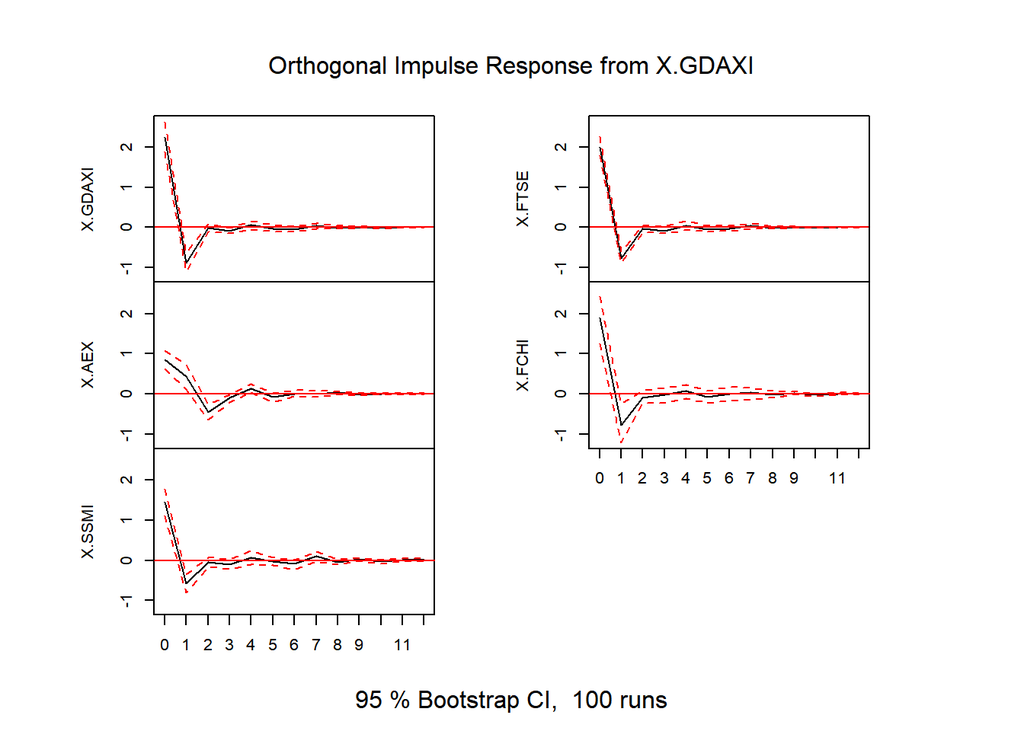

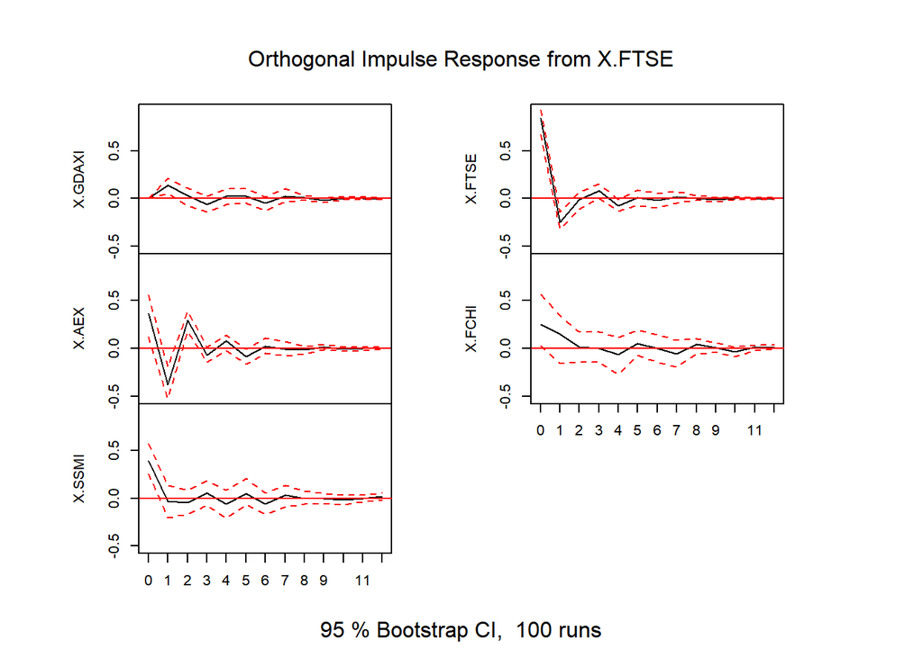

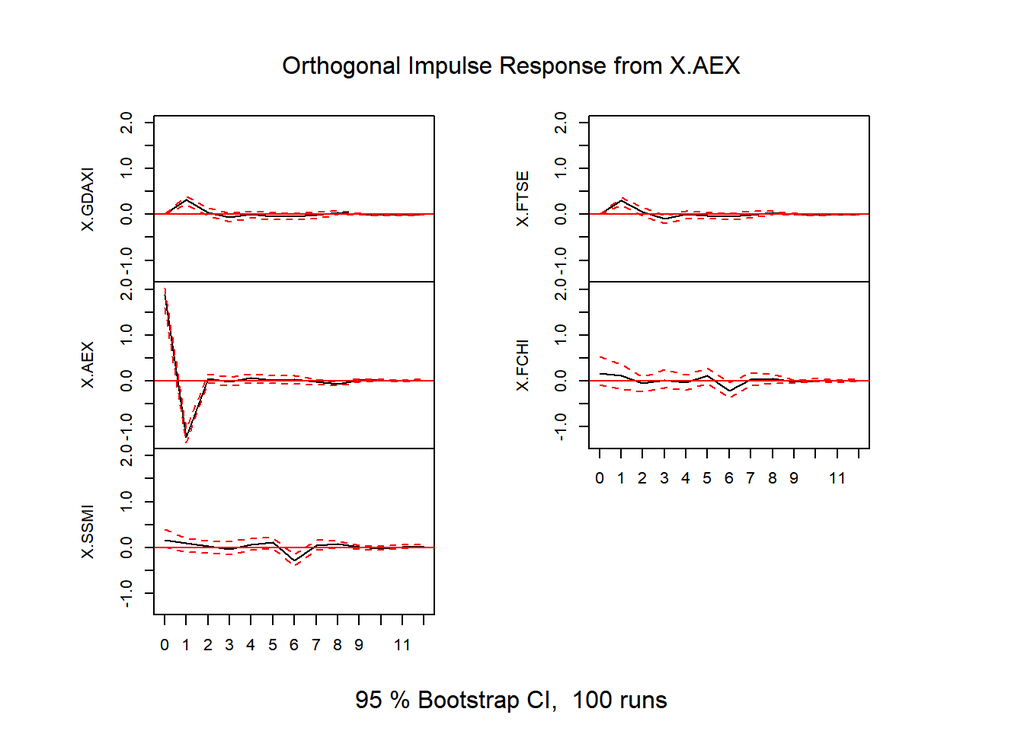

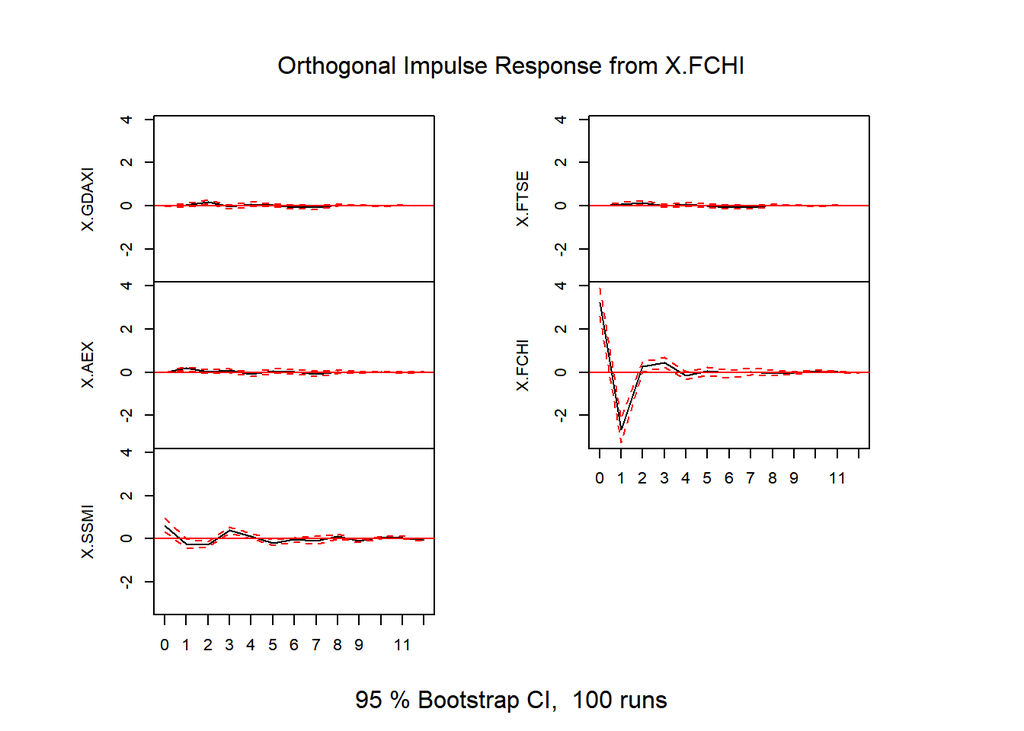

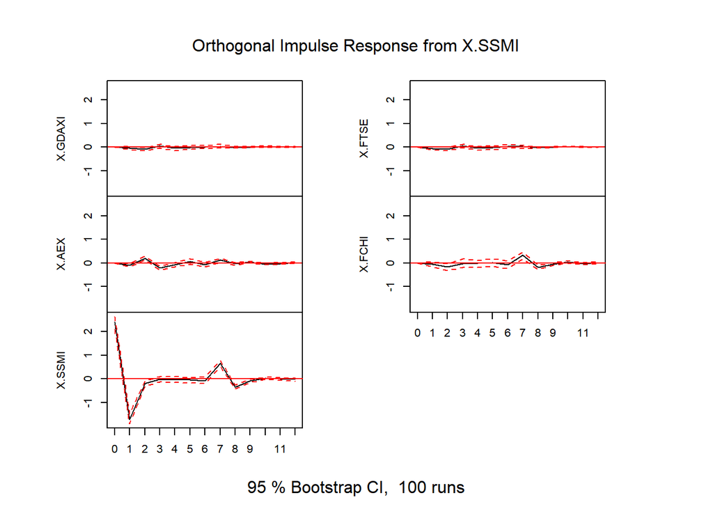

```r
plot(irf(var_europa, n.ahead = 12, boot = TRUE))
```

Como é comum nesse tipo de análise os intervalos de confiança fazem com que poucos períodos tenha funções impulso resposta significativamente diferentes de zero.

Agora façamos os testes para causalidade de Granger

```r
causality(var_europa,cause="X.GDAXI")
```

```
## $Granger
##
##  Granger causality H0: X.GDAXI do not Granger-cause X.FTSE X.AEX
##  X.FCHI X.SSMI
##
## data:  VAR object var_europa
## F-Test = 9.9124, df1 = 24, df2 = 13740, p-value < 2.2e-16
##
##
## $Instant
##
##  H0: No instantaneous causality between: X.GDAXI and X.FTSE X.AEX
##  X.FCHI X.SSMI
##
## data:  VAR object var_europa
## Chi-squared = 1278.8, df = 4, p-value < 2.2e-16
```

```r
causality(var_europa,cause="X.FTSE")
```

```
## $Granger
##
##  Granger causality H0: X.FTSE do not Granger-cause X.GDAXI X.AEX
##  X.FCHI X.SSMI
##
## data:  VAR object var_europa
## F-Test = 4.0498, df1 = 24, df2 = 13740, p-value = 9.979e-11
##
##
## $Instant
##
##  H0: No instantaneous causality between: X.FTSE and X.GDAXI X.AEX
##  X.FCHI X.SSMI
##
## data:  VAR object var_europa
## Chi-squared = 1282.6, df = 4, p-value < 2.2e-16
```

```r
causality(var_europa,cause="X.AEX")
```

```
## $Granger
##
##  Granger causality H0: X.AEX do not Granger-cause X.GDAXI X.FTSE
##  X.FCHI X.SSMI
##
## data:  VAR object var_europa
## F-Test = 4.7718, df1 = 24, df2 = 13740, p-value = 1.059e-13
##
##
## $Instant
##
##  H0: No instantaneous causality between: X.AEX and X.GDAXI X.FTSE
##  X.FCHI X.SSMI
##
## data:  VAR object var_europa
## Chi-squared = 457.88, df = 4, p-value < 2.2e-16
```

```r
causality(var_europa,cause="X.FCHI")
```

```
## $Granger
##
##  Granger causality H0: X.FCHI do not Granger-cause X.GDAXI X.FTSE
##  X.AEX X.SSMI
##
## data:  VAR object var_europa
## F-Test = 6.4959, df1 = 24, df2 = 13740, p-value < 2.2e-16
##
##
## $Instant
##
##  H0: No instantaneous causality between: X.FCHI and X.GDAXI X.FTSE
##  X.AEX X.SSMI
##
## data:  VAR object var_europa
## Chi-squared = 650.25, df = 4, p-value < 2.2e-16
```

```r
causality(var_europa,cause="X.SSMI")
```

```
## $Granger
##
##  Granger causality H0: X.SSMI do not Granger-cause X.GDAXI X.FTSE
##  X.AEX X.FCHI
##
## data:  VAR object var_europa
## F-Test = 3.8008, df1 = 24, df2 = 13740, p-value = 9.875e-10
##
##
## $Instant
##
##  H0: No instantaneous causality between: X.SSMI and X.GDAXI X.FTSE
##  X.AEX X.FCHI
##
## data:  VAR object var_europa
## Chi-squared = 666.04, df = 4, p-value < 2.2e-16
```

Vemos que todas as variáveis causam e são causadas no sentido de granger tanto no período recente quanto a posteriori, isso confirma minha expectativa da alta correlação dessas variáveis.

# Letra e

Vamos realizar o teste do traço de johansen para cointegração, não colocarei sasonaldiade mas colocarei uma constante, faço isso pois como utilizarei as variáveis cruas pode ser que um intercepto melhore a análise.

```r
summary(ca.jo(prices, type = "trace", ecdet = "const",K = 6))
```

```
##
## ######################
## # Johansen-Procedure #
## ######################
##
## Test type: trace statistic , without linear trend and constant in cointegration
##
## Eigenvalues (lambda):
## [1]  9.767578e-03  6.543469e-03  5.230128e-03  3.226073e-03  1.502165e-03
## [6] -9.970257e-19
##
## Values of teststatistic and critical values of test:
##
##           test 10pct  5pct  1pct
## r <= 4 |  4.18  7.52  9.24 12.97
## r <= 3 | 13.16 17.85 19.96 24.60
## r <= 2 | 27.73 32.00 34.91 41.07
## r <= 1 | 45.97 49.65 53.12 60.16
## r = 0  | 73.25 71.86 76.07 84.45
##
## Eigenvectors, normalised to first column:
## (These are the cointegration relations)
##
##              X.GDAXI.l6     X.FTSE.l6      X.AEX.l6  X.FCHI.l6
## X.GDAXI.l6   1.00000000  1.000000e+00   1.000000000  1.0000000
## X.FTSE.l6   -0.12634779 -2.514629e-01  -0.068367523 -0.5329200
## X.AEX.l6    -0.03844023  4.563966e-01   0.001525093  0.1793860
## X.FCHI.l6   -0.01119440 -1.619360e-01  -0.005718816  0.1199726
## X.SSMI.l6    0.04663179  8.825731e-02  -0.023117528 -0.0383735
## constant   113.77808647 -1.429646e+03 105.941653904 -4.8850073
##                X.SSMI.l6     constant
## X.GDAXI.l6  1.000000e+00   1.00000000
## X.FTSE.l6  -4.411926e-02  -0.14415363
## X.AEX.l6   -2.305032e-02  -0.07724799
## X.FCHI.l6   2.818702e-03   0.06826512
## X.SSMI.l6   1.831253e-03   0.01462902
## constant   -1.156679e+02 282.53672844
##
## Weights W:
## (This is the loading matrix)
##
##             X.GDAXI.l6     X.FTSE.l6     X.AEX.l6     X.FCHI.l6
## X.GDAXI.d  0.008830046  0.0007674081 -0.004105259  9.979743e-04
## X.FTSE.d   0.168188607  0.0066950937  0.040009673  1.196448e-02
## X.AEX.d    0.275923337 -0.0343333535  0.096167988  9.727136e-05
## X.FCHI.d   0.299960009  0.0916949314  0.513674820 -4.775589e-03
## X.SSMI.d  -0.423658543 -0.0037481233  0.511280676  1.766003e-02
##              X.SSMI.l6      constant
## X.GDAXI.d -0.004738834  8.324848e-18
## X.FTSE.d  -0.034705923  2.850547e-16
## X.AEX.d   -0.067296163  6.719179e-16
## X.FCHI.d  -0.173155577  3.317459e-16
## X.SSMI.d  -0.092893124 -3.064516e-16
```

Podemos ver pelo teste de Johansen apontou que a 10% de significancia há uma relação de cointegração entre essas variáveis.

# Letra f

Como foi encontrado um vetor de cointegração vamos estimá-lo

```r
vecm <- ca.jo(prices, type = "trace", ecdet = "const", K = 6)
vecm.r2 <- cajorls(vecm, r = 1)
summary(vecm.r2$rlm)
```

```
## Response X.GDAXI.d :
##
## Call:
## lm(formula = X.GDAXI.d ~ ect1 + X.GDAXI.dl1 + X.FTSE.dl1 + X.AEX.dl1 +
##     X.FCHI.dl1 + X.SSMI.dl1 + X.GDAXI.dl2 + X.FTSE.dl2 + X.AEX.dl2 +
##     X.FCHI.dl2 + X.SSMI.dl2 + X.GDAXI.dl3 + X.FTSE.dl3 + X.AEX.dl3 +
##     X.FCHI.dl3 + X.SSMI.dl3 + X.GDAXI.dl4 + X.FTSE.dl4 + X.AEX.dl4 +
##     X.FCHI.dl4 + X.SSMI.dl4 + X.GDAXI.dl5 + X.FTSE.dl5 + X.AEX.dl5 +
##     X.FCHI.dl5 + X.SSMI.dl5 - 1, data = data.mat)
##
## Residuals:
##      Min       1Q   Median       3Q      Max
## -138.969   -2.748    0.282    3.281  154.295
##
## Coefficients:
##               Estimate Std. Error t value Pr(>|t|)
## ect1         0.0088300  0.0077227   1.143 0.252979
## X.GDAXI.dl1 -0.5029523  0.0546846  -9.197  < 2e-16 ***
## X.FTSE.dl1   0.0043061  0.0050766   0.848 0.396390
## X.AEX.dl1    0.0096995  0.0014482   6.698 2.56e-11 ***
## X.FCHI.dl1   0.0001669  0.0006028   0.277 0.781963
## X.SSMI.dl1  -0.0004007  0.0008898  -0.450 0.652481
## X.GDAXI.dl2 -0.3867772  0.0605644  -6.386 1.99e-10 ***
## X.FTSE.dl2   0.0085830  0.0055539   1.545 0.122362
## X.AEX.dl2    0.0115948  0.0017470   6.637 3.85e-11 ***
## X.FCHI.dl2   0.0036238  0.0007774   4.661 3.29e-06 ***
## X.SSMI.dl2  -0.0023490  0.0010612  -2.214 0.026943 *
## X.GDAXI.dl3 -0.1574229  0.0618434  -2.546 0.010966 *
## X.FTSE.dl3  -0.0042853  0.0056967  -0.752 0.451972
## X.AEX.dl3    0.0089009  0.0018396   4.838 1.38e-06 ***
## X.FCHI.dl3   0.0024434  0.0008596   2.843 0.004508 **
## X.SSMI.dl3  -0.0019274  0.0011279  -1.709 0.087595 .
## X.GDAXI.dl4 -0.0344759  0.0605044  -0.570 0.568855
## X.FTSE.dl4  -0.0054719  0.0055641  -0.983 0.325480
## X.AEX.dl4    0.0060735  0.0017445   3.481 0.000506 ***
## X.FCHI.dl4   0.0020193  0.0008145   2.479 0.013222 *
## X.SSMI.dl4  -0.0019031  0.0010856  -1.753 0.079686 .
## X.GDAXI.dl5 -0.0331673  0.0558443  -0.594 0.552612
## X.FTSE.dl5  -0.0023655  0.0051375  -0.460 0.645235
## X.AEX.dl5    0.0023997  0.0013929   1.723 0.085034 .
```

[output cut: 193 more lines]

```
## X.FTSE.dl4   0.171306   0.144507   1.185 0.235940
## X.AEX.dl4    0.035072   0.045307   0.774 0.438937
## X.FCHI.dl4   0.073018   0.021152   3.452 0.000565 ***
## X.SSMI.dl4  -0.231963   0.028193  -8.228 2.91e-16 ***
## X.GDAXI.dl5 -1.202384   1.450343  -0.829 0.407157
## X.FTSE.dl5   0.120382   0.133427   0.902 0.367013
## X.AEX.dl5    0.147602   0.036175   4.080 4.63e-05 ***
## X.FCHI.dl5   0.052340   0.016983   3.082 0.002078 **
## X.SSMI.dl5  -0.129200   0.024143  -5.351 9.44e-08 ***
## ---
## Signif. codes:  0 '***' 0.001 '**' 0.01 '*' 0.05 '.' 0.1 ' ' 1
##
## Residual standard error: 220 on 2753 degrees of freedom
## Multiple R-squared:  0.2937, Adjusted R-squared:  0.287
## F-statistic: 44.02 on 26 and 2753 DF,  p-value: < 2.2e-16
```

Podemos ver que a relação de cointegração foi significativa para a inglaterra, holanda e suiça, enquanto para a frança e alemanha não houve significancia da relação de cointegração.

Para aqueles que foram significativos vemos que a suiça tem um coeficiente de ajustamento negativo e a inglaterra e a holanda tem coeficientes positivos indicando que de fato a principal cointegração se da entre essas três variáveis.

## Questão 2

# Letra a

Vou utilizar para modelar cada série individualmente a distribuição t padrão com assimetria o interesse nessa assimetria se da pelos fatos estilizados das séries financeiras indicarem caudas grossas e leve assimetria a esquerda,, fatos estilizados confirmados anteriormente quando verificamos os momentos amostrais das nossas séries. Para estimar a densidade conjunta eu utilizei uma t multivariada devido a possibilidade da curtose ser verificada também na interelação entre as séries.

```r
spec1 <- ugarchspec(distribution = "sstd")
mspec <- multispec(c(spec1,spec1,spec1,spec1,spec1))
dcc.spec<-dccspec(mspec,distribution="mvt")
d.fit.2<-dccfit(dcc.spec,returns)
```

# Letra b

Reportamos os parametros estimados

```r
d.fit.2
```

```
##
## *---------------------------------*
## *          DCC GARCH Fit          *
## *---------------------------------*
##
## Distribution         :  mvt
## Model                :  DCC(1,1)
## No. Parameters       :  53
## [VAR GARCH DCC UncQ] : [0+40+3+10]
## No. Series           :  5
## No. Obs.             :  2784
## Log-Likelihood       :  -17497.42
## Av.Log-Likelihood    :  -6.28
##
## Optimal Parameters
## -----------------------------------
##                  Estimate  Std. Error   t value Pr(>|t|)
## [^GDAXI].mu      0.059529    0.245511   0.24247 0.808416
## [^GDAXI].ar1     0.928249    0.183590   5.05610 0.000000
## [^GDAXI].ma1    -0.951568    0.119552  -7.95946 0.000000
## [^GDAXI].omega   0.165070    0.060812   2.71443 0.006639
## [^GDAXI].alpha1  0.321307    0.080133   4.00968 0.000061
## [^GDAXI].beta1   0.677691    0.061871  10.95332 0.000000
## [^GDAXI].skew    0.949118    0.154643   6.13747 0.000000
## [^GDAXI].shape   3.530814    0.532042   6.63634 0.000000
## [^FTSE].mu       0.057245    0.020450   2.79920 0.005123
## [^FTSE].ar1      0.763888    0.399188   1.91361 0.055670
## [^FTSE].ma1     -0.819909    0.357301  -2.29473 0.021749
## [^FTSE].omega    0.295668    0.102922   2.87273 0.004069
## [^FTSE].alpha1   0.320491    0.059336   5.40132 0.000000
## [^FTSE].beta1    0.652515    0.042077  15.50768 0.000000
## [^FTSE].skew     0.947795    0.023309  40.66228 0.000000
## [^FTSE].shape    3.380838    0.371611   9.09779 0.000000
## [^AEX].mu        0.034469    0.016935   2.03545 0.041806
## [^AEX].ar1       0.895431    0.095696   9.35704 0.000000
## [^AEX].ma1      -0.944680    0.070186 -13.45964 0.000000
## [^AEX].omega     1.093560    0.354869   3.08159 0.002059
## [^AEX].alpha1    0.709422    0.131175   5.40822 0.000000
## [^AEX].beta1     0.289577    0.072771   3.97932 0.000069
## [^AEX].skew      0.939426    0.021574  43.54385 0.000000
```

[output cut: 16 more lines]

```
## [^SSMI].shape    2.334166    0.087089  26.80193 0.000000
## [Joint]dcca1     0.256361    0.014667  17.47850 0.000000
## [Joint]dccb1     0.728974    0.015852  45.98716 0.000000
## [Joint]mshape    4.000000    0.276180  14.48328 0.000000
##
## Information Criteria
## ---------------------
##
## Akaike       12.608
## Bayes        12.721
## Shibata      12.607
## Hannan-Quinn 12.649
##
##
## Elapsed time : 1.373956
```

# Letra C

Monta um gráfico contendo as variancias condicionais agrupadas.

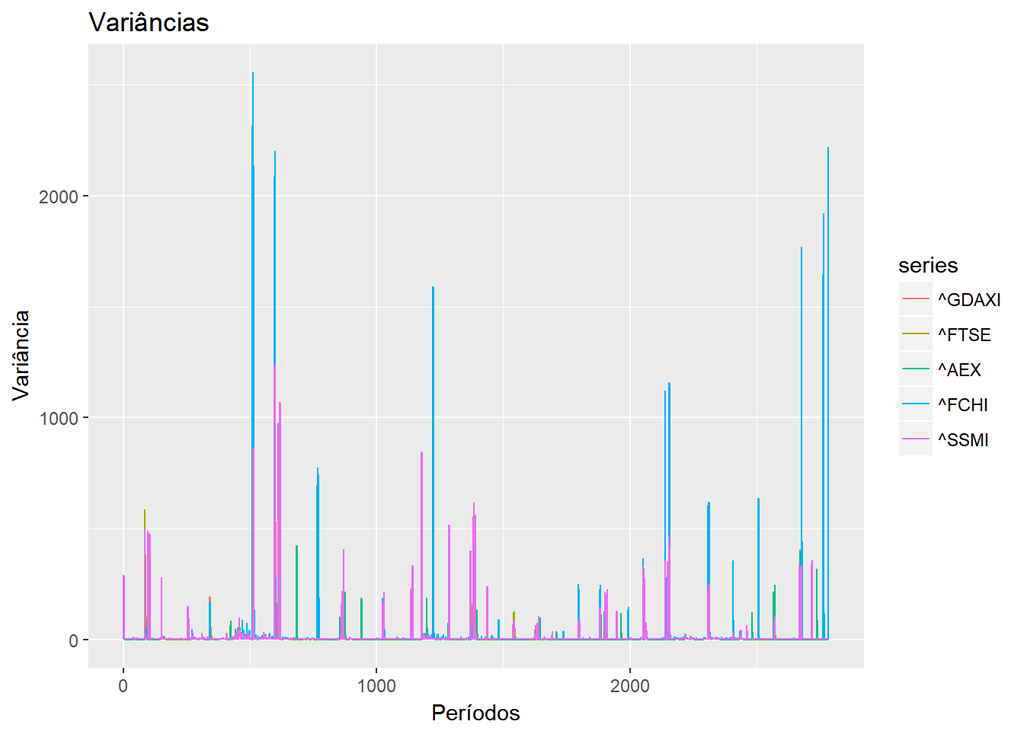

```r
cov.dcc <- rcov(d.fit.2)
var_cov<-as.ts(cbind(cov.dcc[1,1,],cov.dcc[2,2,],cov.dcc[3,3,],cov.dcc[4,4,],cov.dcc[5,5,]))
colnames(var_cov)<-names(returns)
autoplot(var_cov,main="Variâncias",xlab="Períodos",ylab="Variância")
```

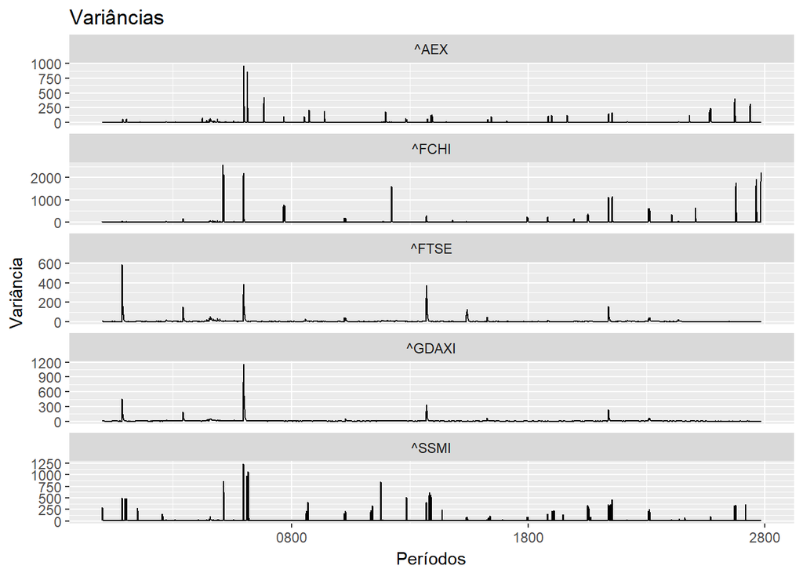

```r
autoplot(as.xts(var_cov),main="Variâncias",xlab="Períodos",ylab="Variância")
```

Monta gráficos que colocam a variância e as covariancias de cada ativo em um gráfico individual

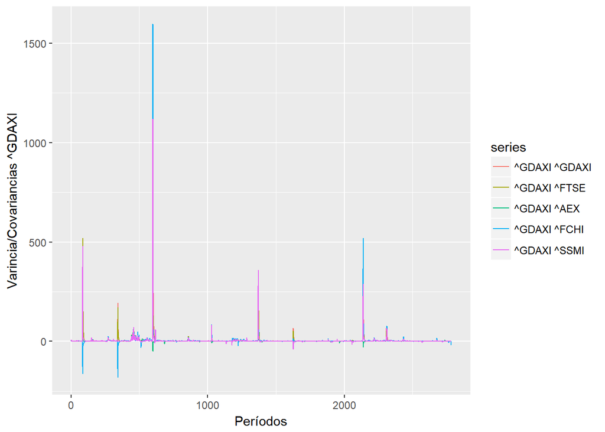

```r
covs_cada_ativo<-list()
for (i in 1:5){
  covs_cada_ativo[[i]]<-matrix(0,nrow=nrow(var_cov),ncol=5)
  for(j in 1:5){
    serie<-matrix(cov.dcc[i,j,])
    covs_cada_ativo[[i]][,j]<-serie
  }
  colnames(covs_cada_ativo[[i]])<-paste(symbols[i],symbols)
}
autoplot(as.ts(covs_cada_ativo[[1]]),xlab="Períodos",ylab=paste("Varincia/Covariancias",symbols[1]))
```

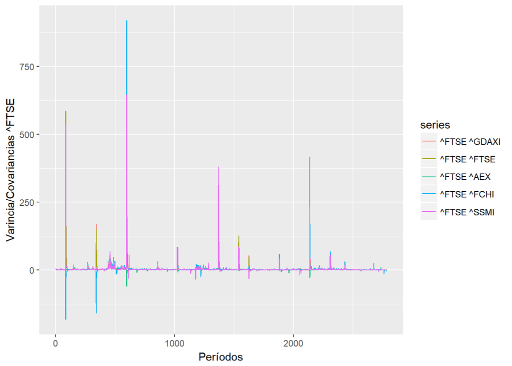

```r
autoplot(as.ts(covs_cada_ativo[[2]]),xlab="Períodos",ylab=paste("Varincia/Covariancias",symbols[2]))
```

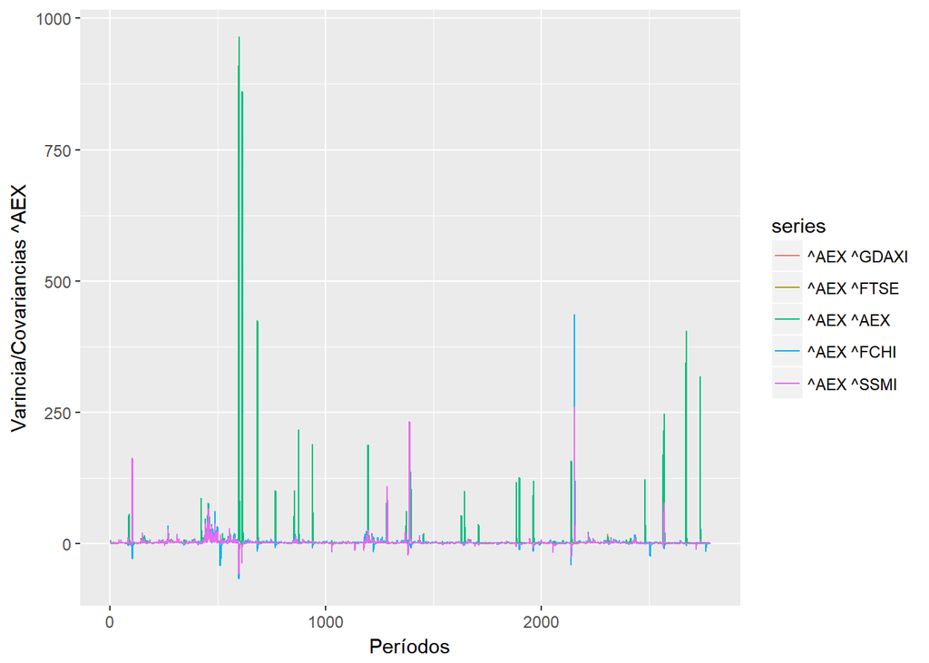

```r
autoplot(as.ts(covs_cada_ativo[[3]]),xlab="Períodos",ylab=paste("Varincia/Covariancias",symbols[3]))
```

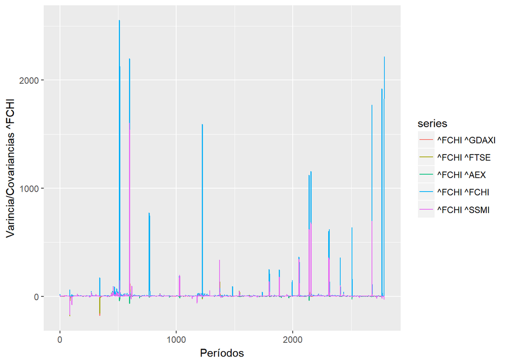

```r
autoplot(as.ts(covs_cada_ativo[[4]]),xlab="Períodos",ylab=paste("Varincia/Covariancias",symbols[4]))
```

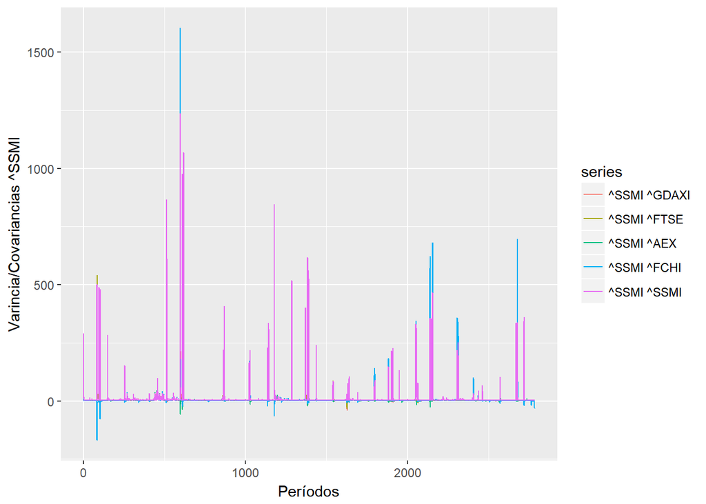

```r
autoplot(as.ts(covs_cada_ativo[[5]]),xlab="Períodos",ylab=paste("Varincia/Covariancias",symbols[5]))
```

Monta um gráfico demonstrando como o relacionamento da matriz de covariancia se da pra cada serie no formato de uma matriz de variancias e covariancias.

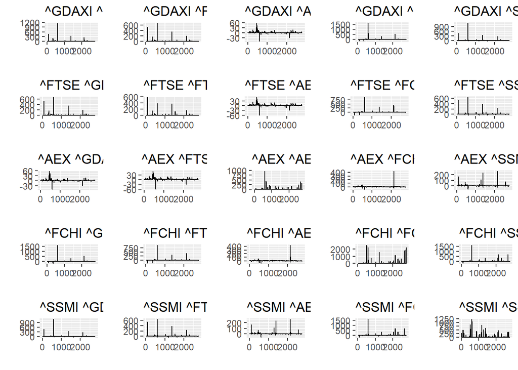

```r
covariancias<-list()
proxima<-0
for (i in 1:5){
    for(j in 1:5){
    ts<-as.ts(matrix(cov.dcc[i,j,]))
    names<-paste(symbols[i],symbols[j])
    covariancias[[proxima+j]]<-autoplot(ts,main=names)
    }
  proxima<-proxima+5
}

grid.arrange(covariancias[[1]],covariancias[[2]],covariancias[[3]],covariancias[[4]],covariancias[[5]],
             covariancias[[6]],covariancias[[7]],covariancias[[8]],covariancias[[9]],covariancias[[10]],
             covariancias[[11]],covariancias[[12]],covariancias[[13]],covariancias[[14]],covariancias[[15]],
             covariancias[[16]],covariancias[[17]],covariancias[[18]],covariancias[[19]],covariancias[[20]],
             covariancias[[21]],covariancias[[22]],covariancias[[23]],covariancias[[24]],covariancias[[25]],
             ncol=5, nrow=5)
```

# Letra d

Monta um gráfico contendo as correlações condicionais agrupadas.

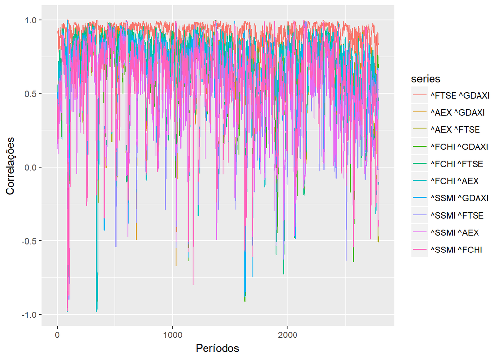

```r
corr.dcc<-rcor(d.fit.2)
var_corr<-as.ts(cbind(corr.dcc[1,2,],corr.dcc[1,3,],corr.dcc[1,4,],corr.dcc[1,5,],
                     corr.dcc[2,3,],corr.dcc[2,4,],corr.dcc[2,5,],
                     corr.dcc[3,4,],corr.dcc[3,5,],
                     corr.dcc[4,5,]))



nomes<-rep("names",times=(ncol(var_corr)))
count<-1
for (i in 2:5){
  for(j in 1:(i-1)){
    nomes[count]<-paste(symbols[i],symbols[j])
    count<-count+1
  }
}
colnames(var_corr)<-nomes
autoplot(var_corr,ylab="Correlações",xlab="Períodos")
```

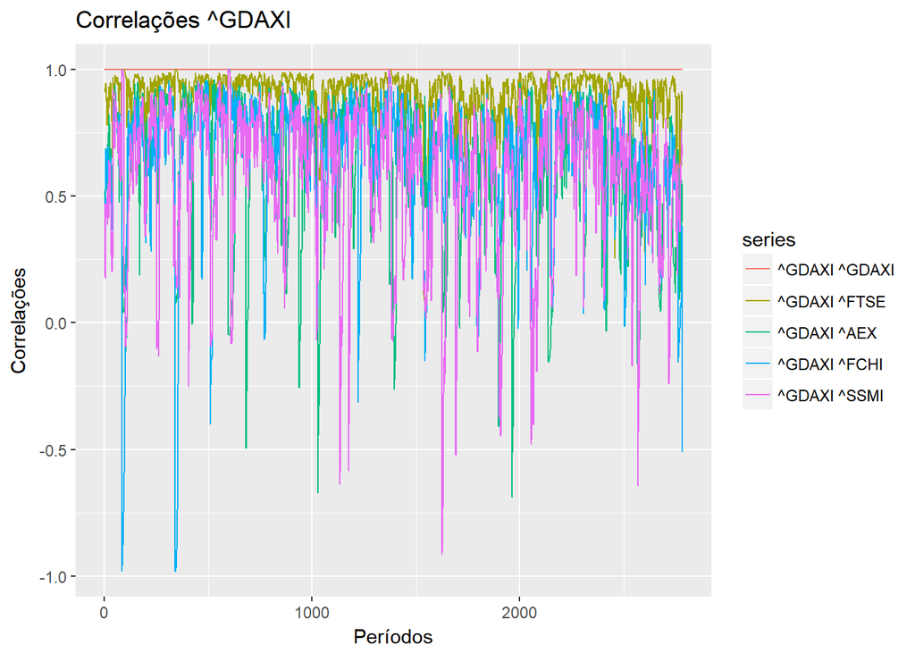

```r
corrs_cada_ativo<-list()
for (i in 1:5){
  corrs_cada_ativo[[i]]<-matrix(0,nrow=nrow(var_corr),ncol=5)
  for(j in 1:5){
    serie<-matrix(corr.dcc[i,j,])
    corrs_cada_ativo[[i]][,j]<-serie
  }
  colnames(corrs_cada_ativo[[i]])<-paste(symbols[i],symbols)
}

for(i in 1:5){
  autoplot(as.ts(corrs_cada_ativo[[i]]),main=paste("Correlações",symbols[i]))
}

autoplot(as.ts(corrs_cada_ativo[[1]]),main=paste("Correlações",symbols[1]),ylab="Correlações",xlab="Períodos")
```

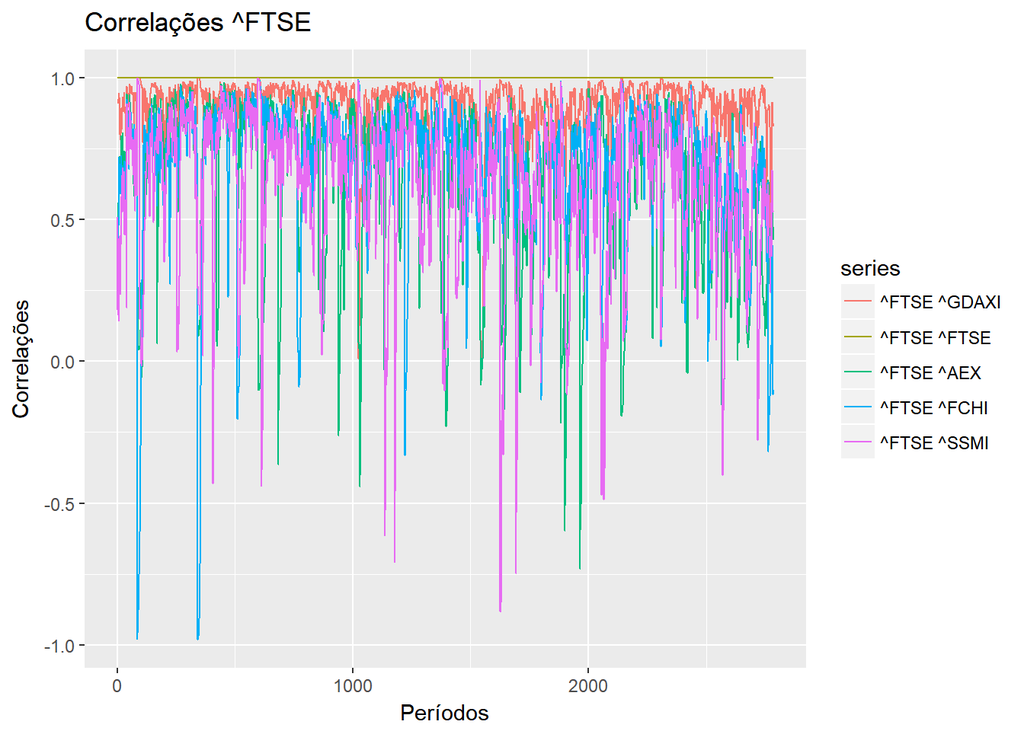

```r
autoplot(as.ts(corrs_cada_ativo[[2]]),main=paste("Correlações",symbols[2]),ylab="Correlações",xlab="Períodos")
```

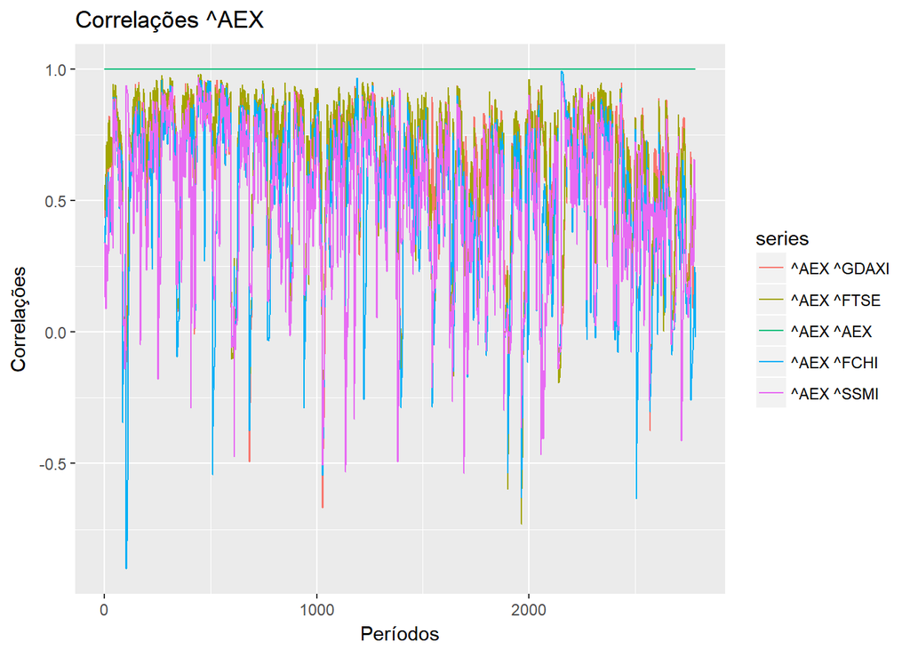

```r
autoplot(as.ts(corrs_cada_ativo[[3]]),main=paste("Correlações",symbols[3]),ylab="Correlações",xlab="Períodos")
```

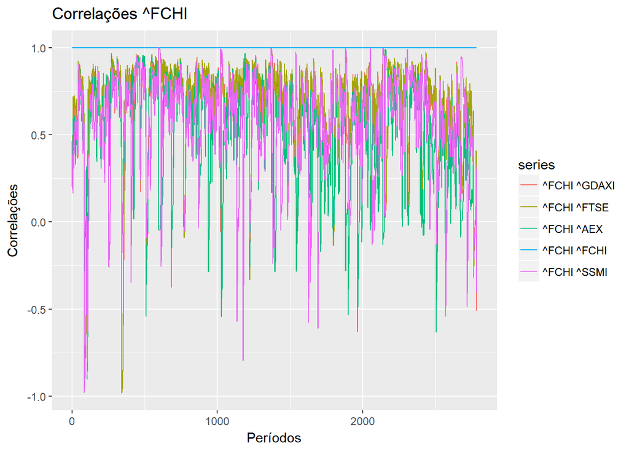

```r
autoplot(as.ts(corrs_cada_ativo[[4]]),main=paste("Correlações",symbols[4]),ylab="Correlações",xlab="Períodos")
```

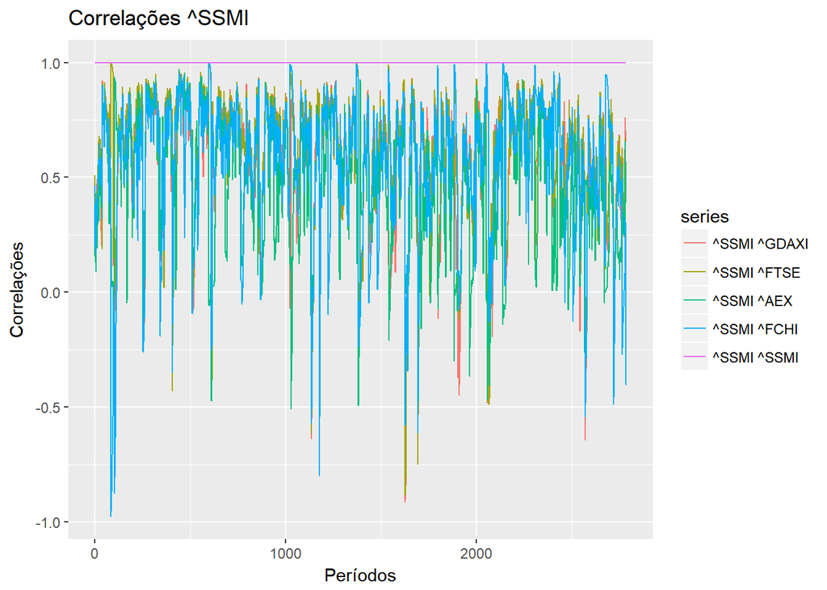

```r
autoplot(as.ts(corrs_cada_ativo[[5]]),main=paste("Correlações",symbols[5]),ylab="Correlações",xlab="Períodos")
```

Monta um gráfico demonstrando como o relacionamento da matriz de correlações se da pra cada serie individualmente no formato de uma matriz de correlações.

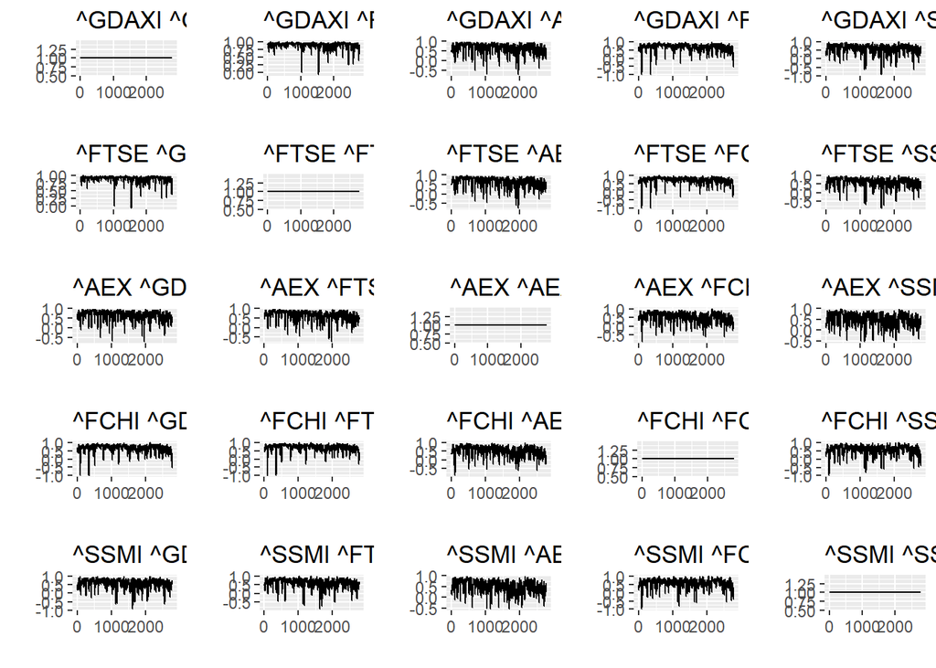

```r
correlacoes<-list()
proxima<-0
for (i in 1:5){
    for(j in 1:5){
    ts<-as.ts(matrix(corr.dcc[i,j,]))
    names<-paste(symbols[i],symbols[j])
    correlacoes[[proxima+j]]<-autoplot(ts,main=names)
    }
  proxima<-proxima+5
}

grid.arrange(correlacoes[[1]],correlacoes[[2]],correlacoes[[3]],correlacoes[[4]],correlacoes[[5]],
             correlacoes[[6]],correlacoes[[7]],correlacoes[[8]],correlacoes[[9]],correlacoes[[10]],
             correlacoes[[11]],correlacoes[[12]],correlacoes[[13]],correlacoes[[14]],correlacoes[[15]],
             correlacoes[[16]],correlacoes[[17]],correlacoes[[18]],correlacoes[[19]],correlacoes[[20]],
             correlacoes[[21]],correlacoes[[22]],correlacoes[[23]],correlacoes[[24]],correlacoes[[25]],
             ncol=5, nrow=5)
```